# Ant Colony Optimization with antColony()

```r
library(ShortForm)
```

## How it works

The Ant Colony Optimization (ACO) algorithm (Dorigo & Stutzle, 2004; adapted for short-form construction by [Leite, Huang, & Marcoulides, 2008](https://doi.org/10.1080/00273170802285743)) is based on the foraging behavior of ants: they search for food in a variety of directions, and the shortest paths accumulate the strongest pheromone trails, which then attract more ants.

Applied to short-form construction:

1. A number of “ants” (candidate short forms) are sampled per iteration, with items selected with probability proportional to their current “pheromone” weight.
2. Each candidate model is fit, and checked against a fit-based threshold test (`fit.statistics.test`).
3. Candidates that pass the threshold have a “pheromone” strength computed from their fit (`pheromone.calculation`); the best candidate’s items have pheromone added to their weight, making them more likely to be sampled again.
4. This repeats until the same solution is chosen for a set number of ants in a row (`steps`), or `maxIterations` ants have been tried in total.

## A basic example

Every candidate item must already appear on its factor’s line in `initialModel` – `antColony()` derives the factor names and each factor’s candidate item pool directly from that syntax, the same way `simulatedAnnealing()` and `tabuSearch()` do.

```r
set.seed(58310)

result <- antColony(
  data = lavaan::HolzingerSwineford1939,
  ants = 2, evaporation = 0.7,
  initialModel = " visual  =~ x1 + x2 + x3
                   textual =~ x4 + x5 + x6
                   speed   =~ x7 + x8 + x9 ",
  itemsPerFactor = c(3, 3, 3),
  steps = 2,
  fit.indices = c("cfi"),
  fit.statistics.test = "(cfi > 0.6)",
  maxIterations = 2,
  parallel = FALSE,
  verbose = FALSE
)

result
```

```
#> Algorithm: Ant Colony Optimization
#> Total Run Time: 0.095 secs
#>
#> Function call:
#> antColony(data = lavaan::HolzingerSwineford1939, ants = 2, evaporation = 0.7,
#>   initialModel = " visual =~ x1 + x2 + x3\n textual =~ x4 + x5 + x6\n speed
#>   =~ x7 + x8 + x9 ", itemsPerFactor = c(3, 3, 3), steps = 2, fit.indices =
#>   c("cfi"), fit.statistics.test = "(cfi > 0.6)", maxIterations = 2, parallel =
#>   FALSE, verbose = FALSE, sample.cov = NULL, sample.nobs = NULL, items = NULL,
#>   bifactor = NULL, lavaan.model.specs = list(model.type = "cfa", estimator
#>   = "default", ordered = NULL, int.ov.free = TRUE, int.lv.free = FALSE,
#>   auto.fix.first = TRUE, auto.fix.single = TRUE, auto.var = TRUE, auto.cov.lv.x
#>   = TRUE, auto.th = TRUE, auto.delta = TRUE, auto.cov.y = TRUE, std.lv = FALSE,
#>   group = NULL, group.label = NULL, group.equal = "loadings", group.partial =
#>   NULL, group.w.free = FALSE), pheromone.calculation = "gamma")
#>
#> Final Model Syntax:
#> visual =~ x1 + x2 + x3
#> textual =~ x4 + x5 + x6
#> speed =~ x7 + x8 + x9
#>
#> Fit Indices: cfi
#> Fit Test: (cfi > 0.6)
#> Final Model Values: cfi = 0.931
```

`itemsPerFactor` sets the target number of items to keep for each factor, in the order the factors appear in `initialModel`. Since this toy example already asks to keep all 3 items per factor, the “search” has only one candidate to find.

## Inspecting the result

```r
summary(result)
```

```
#> Algorithm: Ant Colony Optimization
#> Total Run Time: 0.095 secs
#>
#> lavaan 0.7-2 ended normally after 35 iterations
#>
#>   Estimator                                         ML
#>   Optimization method                           NLMINB
#>   Number of model parameters                        30
#>
#>   Number of observations                           301
#>
#> Model Test User Model:
#>
#>   Test statistic                                85.306
#>   Degrees of freedom                                24
#>   P-value (Chi-square)                           0.000
#>
#>
#> Final Model Syntax:
#> visual =~ x1 + x2 + x3
#> textual =~ x4 + x5 + x6
#> speed =~ x7 + x8 + x9
#>
#> Fit Indices: cfi
#> Fit Test: (cfi > 0.6)
#> Final Model Values: cfi = 0.931
```

`plot()` shows several diagnostics: how the pheromone accumulates across runs, and how the mean standardized loadings/variance explained change.

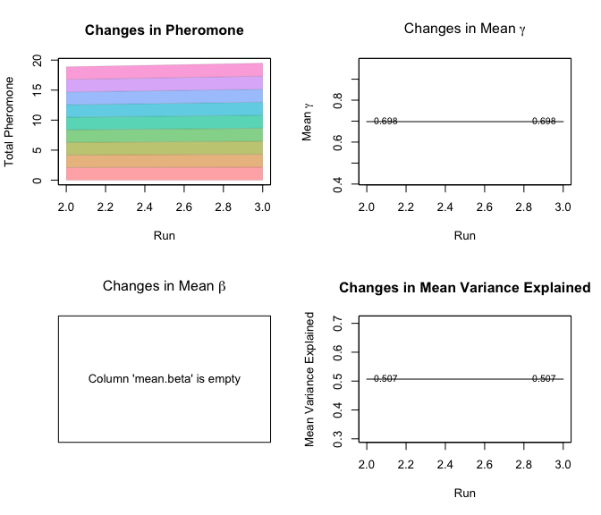

```r
plot(result)
```

You can also request a single panel:

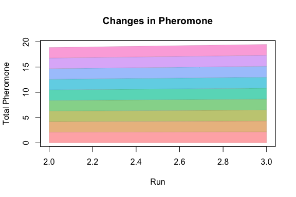

```r
plot(result, type = "pheromone")
```

## A more realistic example

The toy example above doesn’t actually reduce the item bank. A more typical use case starts from a much larger item pool – here, the bundled `exampleAntModel` (56 items on a single `Ability` factor) and `simulated_test_data`:

```r
data(exampleAntModel) # a character vector for a lavaan model
data(simulated_test_data)

abilityShortForm <- antColony(
  data = simulated_test_data,
  ants = 5, evaporation = 0.7,
  initialModel = exampleAntModel,
  itemsPerFactor = 20,
  steps = 3,
  fit.indices = c("cfi", "rmsea"),
  fit.statistics.test = "(cfi > 0.95)&(rmsea < 0.05)",
  maxIterations = 500
)

abilityShortForm
```

## Fit indices, thresholds, and pheromone

- `fit.indices` – which `lavaan::fitmeasures()` values to compute for each candidate (e.g. `c("cfi", "tli", "rmsea")`)
- `fit.statistics.test` – a logical expression over those fit indices that a candidate must satisfy to be considered viable at all (e.g. `"(cfi > 0.95)&(tli > 0.95)&(rmsea < 0.06)"`)
- `pheromone.calculation` – how the *strength* of a viable candidate’s pheromone deposit is computed: `"gamma"` (mean standardized latent regression coefficients), `"beta"` (mean standardized observed regression coefficients), `"regression"` (both), or `"variance"` (mean variance explained)

A candidate that fails `fit.statistics.test` contributes no pheromone at all, regardless of `pheromone.calculation`.

## Ordered (categorical) data

`antColony()` works with categorical/ordered indicators by passing the appropriate `lavaan.model.specs`:

```r
sim_model <- "
f1 =~ x1 + x2 + x3 + x4 + x5 + x6 + x7 + x8 + x9 + x10
f2 =~ x11 + x12 + x13 + x14 + x15 + x16 + x17 + x18 + x19 + x20
f3 =~ x21 + x22 + x23 + x24 + x25 + x26 + x27 + x28 + x29 + x30"

sim_data <- cbind(
  psych::sim.rasch(nvar = 10)$items,
  psych::sim.rasch(nvar = 10)$items,
  psych::sim.rasch(nvar = 10)$items
)
colnames(sim_data) <- paste0("x", 1:30)

# only estimator and ordered are changed -- every other lavaan.model.specs
# element falls back to antColony()'s own default
example <- antColony(
  data = sim_data,
  ants = 5, evaporation = 0.7,
  initialModel = sim_model,
  lavaan.model.specs = list(estimator = "wlsmv", ordered = TRUE),
  itemsPerFactor = c(5, 5, 5),
  steps = 20,
  fit.indices = c("cfi.scaled"),
  fit.statistics.test = "(cfi.scaled > 0.90)",
  maxIterations = 500,
  parallel = TRUE
)
```

`lavaan.model.specs` accepts a *partial* list – any element you omit falls back to `antColony()`’s own default for that element, but every name you do supply must be a recognized `lavaan()` argument, or the call errors immediately (catching typos like `estmator` before a long run starts).

## Bifactor models

Pass the name of the general factor as `bifactor` to have all of the retained items across the other factors also load on it:

```r
bifactorModel <- "
visual  =~ x1 + x2 + x3 + x4 + x5 + x6 + x7 + x8 + x9
textual =~ x4 + x5 + x6
speed   =~ x7 + x8 + x9"

antColony(
  data = lavaan::HolzingerSwineford1939,
  ants = 5, evaporation = 0.7,
  initialModel = bifactorModel,
  itemsPerFactor = c(6, 3, 3),
  bifactor = "visual",
  steps = 5, fit.indices = c("cfi"), fit.statistics.test = "(cfi > 0.9)",
  maxIterations = 100
)
```